# Tasks 1: Exploratory Data Analysis

# 6 Apply model on test set

## 6.1 Test with linear regressor

```python
reg.fit(x_test, y_test)
y_hat_test_lr = reg.predict(x_test)
```

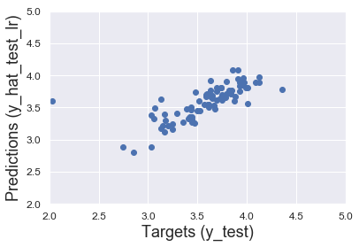

```python
plt.scatter(y_test, y_hat_test_lr)
plt.xlabel('Targets (y_test)',size=18)
plt.ylabel('Predictions (y_hat_test_lr)',size=18)
plt.xlim(2,5)
plt.ylim(2,5)
plt.show()
```

```python
# Compute R2
test_r2_lr=r2_score(y_test, y_hat_test_lr)
test_r2_lr
# Accuracy = 55.85%
```

```
0.5584545516590501
```

```python
# Compute RMSE
test_mse_lr = mean_squared_error(y_test, y_hat_test_lr)
test_rmse_lr = np.sqrt(test_mse_lr)
test_rmse_lr
```

```
0.24175118721966377
```

## 6.2 Test with RF regressor

### 6.2.1 Grid Search on training set (fine-tune)

Using a vary of parameters then it validate with the certain performance metric to return best estimator parameter.

- n_estimators represents the number of trees in the forest. Usually the higher the number of trees the better to learn the data. However, adding a lot of trees can slow down the training process considerably, therefore we do a parameter search to find the sweet spot.
- max_depth represents the depth of each tree in the forest. The deeper the tree, the more splits it has and it captures more information about the data.
- max_features represents the number of features to consider when looking for the best split.

```python
# Search for best combination of hyperparameter values for the RandomForestRegressor:
from sklearn.model_selection import GridSearchCV

param_grid = [
    # try 27 (3x3x3) combinations of hyperparameters
    {'n_estimators': [10, 100, 200], 'max_features': [2, 3, 6], 'max_depth': [9, 11, 13]}]

forest_reg = RandomForestRegressor(random_state=42)
# Train across 10 folds, that's a total of 27*10=270 rounds of training
grid_search = GridSearchCV(forest_reg, param_grid, cv=10,scoring='neg_mean_squared_error', return_train_score=True, n_jobs=-1,verbose=2)
%time grid_search.fit(x_train, y_train)
```

```
Fitting 10 folds for each of 27 candidates, totalling 270 fits
```

```
[Parallel(n_jobs=-1)]: Using backend LokyBackend with 4 concurrent workers.
[Parallel(n_jobs=-1)]: Done  33 tasks      | elapsed:    6.6s
[Parallel(n_jobs=-1)]: Done 154 tasks      | elapsed:   16.4s
[Parallel(n_jobs=-1)]: Done 270 out of 270 | elapsed:   27.0s finished
```

```
Wall time: 27.4 s
```

```
GridSearchCV(cv=10, error_score='raise-deprecating',
       estimator=RandomForestRegressor(bootstrap=True, criterion='mse', max_depth=None,
           max_features='auto', max_leaf_nodes=None,
           min_impurity_decrease=0.0, min_impurity_split=None,
           min_samples_leaf=1, min_samples_split=2,
           min_weight_fraction_leaf=0.0, n_estimators='warn', n_jobs=None,
           oob_score=False, random_state=42, verbose=0, warm_start=False),
       fit_params=None, iid='warn', n_jobs=-1,
       param_grid=[{'n_estimators': [10, 100, 200], 'max_features': [2, 3, 6], 'max_depth': [9, 11, 13]}],
       pre_dispatch='2*n_jobs', refit=True, return_train_score=True,
       scoring='neg_mean_squared_error', verbose=2)
```

```python
# Best hyperparameter combination
grid_search.best_params_
```

```
{'max_depth': 11, 'max_features': 2, 'n_estimators': 200}
```

```python
grid_search.best_estimator_
```

```
RandomForestRegressor(bootstrap=True, criterion='mse', max_depth=11,
           max_features=2, max_leaf_nodes=None, min_impurity_decrease=0.0,
           min_impurity_split=None, min_samples_leaf=1,
           min_samples_split=2, min_weight_fraction_leaf=0.0,
           n_estimators=200, n_jobs=None, oob_score=False, random_state=42,
           verbose=0, warm_start=False)
```

```python
# Score of each hyperparameter combination tested during the grid search
cvres = grid_search.cv_results_
for mean_score, params in zip(cvres["mean_test_score"], cvres["params"]):
    print(np.sqrt(-mean_score), params)
```

```
0.18205391303553323 {'max_depth': 9, 'max_features': 2, 'n_estimators': 10}
0.17306546166123193 {'max_depth': 9, 'max_features': 2, 'n_estimators': 100}
0.1714346825596591 {'max_depth': 9, 'max_features': 2, 'n_estimators': 200}
0.18204039254504678 {'max_depth': 9, 'max_features': 3, 'n_estimators': 10}
0.1736948615337796 {'max_depth': 9, 'max_features': 3, 'n_estimators': 100}
0.17295190538958555 {'max_depth': 9, 'max_features': 3, 'n_estimators': 200}
0.1849320937242372 {'max_depth': 9, 'max_features': 6, 'n_estimators': 10}
0.1789407777522611 {'max_depth': 9, 'max_features': 6, 'n_estimators': 100}
0.1769213692424576 {'max_depth': 9, 'max_features': 6, 'n_estimators': 200}
0.18390735424831173 {'max_depth': 11, 'max_features': 2, 'n_estimators': 10}
0.1724373267403356 {'max_depth': 11, 'max_features': 2, 'n_estimators': 100}
0.17094056252581807 {'max_depth': 11, 'max_features': 2, 'n_estimators': 200}
0.1841503560916472 {'max_depth': 11, 'max_features': 3, 'n_estimators': 10}
0.17433287408213197 {'max_depth': 11, 'max_features': 3, 'n_estimators': 100}
0.17271198379962288 {'max_depth': 11, 'max_features': 3, 'n_estimators': 200}
0.1829837191176397 {'max_depth': 11, 'max_features': 6, 'n_estimators': 10}
0.17930368069085964 {'max_depth': 11, 'max_features': 6, 'n_estimators': 100}
0.17742732986738693 {'max_depth': 11, 'max_features': 6, 'n_estimators': 200}
0.18165822436606818 {'max_depth': 13, 'max_features': 2, 'n_estimators': 10}
0.1719776473770918 {'max_depth': 13, 'max_features': 2, 'n_estimators': 100}
0.1712838272014947 {'max_depth': 13, 'max_features': 2, 'n_estimators': 200}
0.18313710195222535 {'max_depth': 13, 'max_features': 3, 'n_estimators': 10}
0.17352792279855442 {'max_depth': 13, 'max_features': 3, 'n_estimators': 100}
0.1730457110740327 {'max_depth': 13, 'max_features': 3, 'n_estimators': 200}
0.18248407592385113 {'max_depth': 13, 'max_features': 6, 'n_estimators': 10}
0.17889933182043113 {'max_depth': 13, 'max_features': 6, 'n_estimators': 100}
0.17737889555495284 {'max_depth': 13, 'max_features': 6, 'n_estimators': 200}
```

The optimum hyperparameter for our RF model is:

- max_features = 2
- n_estimators = 200
- max_depth: 11
- bootstrap = True

### 6.2.2 Apply model to test set

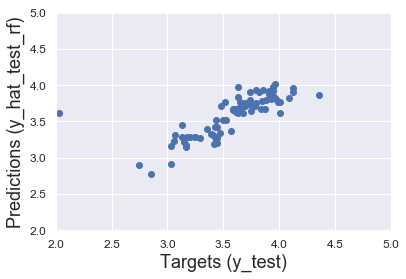

```python
# Evaluate the final model on the test set
final_model = grid_search.best_estimator_
y_hat_test_rf = final_model.predict(x_test)

plt.scatter(y_test, y_hat_test_rf)
plt.xlabel('Targets (y_test)',size=18)
plt.ylabel('Predictions (y_hat_test_rf)',size=18)
plt.xlim(2,5)
plt.ylim(2,5)
plt.show()
```

```python
# Compute final R2
test_r2_rf=r2_score(y_test, y_hat_test_rf)
test_r2_rf
```

```
0.6040408846537275
```

```python
# Compute final RMSE
test_mse_rf = mean_squared_error(y_test, y_hat_test_rf)
test_rmse_rf = np.sqrt(test_mse_rf)
test_rmse_rf
```

```
0.22893177844234514
```

```python
test_rmse = {'Model': ['Linear Regression','Random Tree Regressor'],
        'Test set RMSE': [test_rmse_lr, test_rmse_rf]
        }
test_rmse_df = DataFrame(test_rmse,columns= ['Model', 'Test set RMSE'])
test_rmse_df
```

|  | Model | Test set RMSE |
| --- | --- | --- |
| 0 | Linear Regression | 0.241751 |
| 1 | Random Tree Regressor | 0.228932 |

In this example, we have shown how to perform EDA on a dataset of housing price in Sindian district, train and test the model using both Linear Regressor & RandomTree Regressor.